# 08 — Results and Evaluation

**Primary author:** Victoria

**Builds on:**

- *06_experiments_easy.ipynb* (Victoria — Exp 1A/1B results on the easy random-distractor dataset, `run_experiment()` scaffolding, GroupKFold and hyperparameter tuning design)
- *07_experiments_harder.ipynb* (Victoria — Exp 2A/2B results on the harder cosine-similarity-distractor dataset, central misdirection hypothesis test via the A/B ablation)
- *05_dataset_construction.ipynb* (Victoria — easy and harder dataset construction, distractor strategies per Decisions 6 and 9)
- *03_feature_engineering.ipynb* (Victoria — 47-feature computation logic, feature group column lists extracted to `scripts/feature_utils.py` per Decision 18)
- Hans's *Hans_Supervised_Learning_Models.ipynb* (KNN, LogReg, RF scaffolding — adapted for the full pipeline)

**Prompt engineering:** Victoria  
**AI assistance:** Claude Code (Anthropic)  
**Environment:** Local (CPU only)

This notebook implements **PLAN.md Steps 9–12** (design doc Sections 10.1–10.6):

- **Step 9:** Compile the summary results table (Table 8) comparing all experiments across both datasets, with Δ Easy and Δ Hard.
- **Step 10:** Feature importance, ablation, and retrained best model.
- **Step 11:** Sensitivity analysis.
- **Step 12:** Failure analysis of misclassified examples.

**Input:**

- `outputs/results_easy.csv` (NB 06)
- `outputs/results_harder.csv` (NB 07)
- `outputs/results_harder_per_fold.csv` (NB 07 — per-fold results with best hyperparameters for retraining)
- `data/dataset_harder.parquet` (NB 05 — for retraining the best model)

**Output:**

- `outputs/results_summary.csv` — Table 8 from the design doc
- `outputs/figures/results_summary_table.png` — formatted table figure
- `outputs/figures/feature_importance_gini.png` — Gini importance bar chart
- `outputs/figures/feature_importance_permutation.png` — permutation importance
- `outputs/ablation_results.csv` — group-level ablation results
- `outputs/figures/sensitivity_learning_curve.png` — learning curve
- Trained best model, test predictions, and predicted probabilities (stored in memory for downstream cells)

## 1. Configuration

> **`SAMPLE_MODE`:** Set to `True` (default) for fast iteration with 20,000 rows when retraining the best model. Set to `False` for final runs on the full dataset. The results summary table (Step 9) always loads from the saved CSV files — it reflects whichever mode NB 06/07 were last run in.

```python
import ast
import sys
import warnings

import numpy as np
import pandas as pd
import matplotlib.pyplot as plt
from pathlib import Path

from sklearn.ensemble import RandomForestClassifier
from sklearn.inspection import permutation_importance
from sklearn.metrics import accuracy_score
from sklearn.model_selection import GroupKFold
from sklearn.preprocessing import StandardScaler

warnings.filterwarnings('ignore', category=FutureWarning)

# --- Environment Auto-Detection ---
# Same pattern as prior notebooks: detect Colab vs. local / Great Lakes.
try:
    IS_COLAB = 'google.colab' in str(get_ipython())
except NameError:
    IS_COLAB = False

if IS_COLAB:
    from google.colab import drive
    drive.mount('/content/drive')
    PROJECT_ROOT = Path('/content/drive/MyDrive/SIADS 692 Milestone II/'
                        'Milestone II - NLP Cryptic Crossword Clues/'
                        'clue_misdirection')
else:
    try:
        PROJECT_ROOT = Path(__file__).resolve().parent.parent
    except NameError:
        PROJECT_ROOT = Path.cwd().parent

DATA_DIR = PROJECT_ROOT / 'data'
OUTPUT_DIR = PROJECT_ROOT / 'outputs'
FIGURES_DIR = OUTPUT_DIR / 'figures'
SCRIPTS_DIR = PROJECT_ROOT / 'scripts'
OUTPUT_DIR.mkdir(parents=True, exist_ok=True)
FIGURES_DIR.mkdir(parents=True, exist_ok=True)

# --- Add scripts/ to sys.path so feature_utils is importable ---
# Decision 18: feature column lists are defined in feature_utils.py
# (extracted from NB 03) so all downstream notebooks use the same names.
if str(SCRIPTS_DIR) not in sys.path:
    sys.path.insert(0, str(SCRIPTS_DIR))

from feature_utils import (
    CONTEXT_INFORMED_COLS,
    RELATIONSHIP_COLS,
    SURFACE_COLS,
)

# --- Experiment parameters ---
RANDOM_SEED = 42
N_FOLDS = 5
SAMPLE_MODE = True   # <-- Set to False for final runs
SAMPLE_SIZE = 20_000

# --- Feature set for the harder dataset (Exp 2A) ---
# The harder dataset excludes the 15 context-free cosine features
# (Decision 6: artifacts of cosine-similarity-based distractor
# construction). The remaining 32 features are:
#   6 context-informed + 22 relationship + 4 surface
HARDER_FEATURE_COLS = (
    CONTEXT_INFORMED_COLS + list(RELATIONSHIP_COLS) + SURFACE_COLS
)

# --- Feature group definitions for ablation ---
# Each group maps to a conceptually distinct set of features.
# These are the same groups defined in feature_utils.py.
FEATURE_GROUPS = {
    'Context-Informed (6)': CONTEXT_INFORMED_COLS,
    'Relationship (22)': list(RELATIONSHIP_COLS),
    'Surface (4)': SURFACE_COLS,
}

print(f'Environment: {"Google Colab" if IS_COLAB else "Local / Great Lakes"}')
print(f'Project root: {PROJECT_ROOT}')
print(f'Data directory: {DATA_DIR}')
print(f'Output directory: {OUTPUT_DIR}')
print(f'\nRandom seed: {RANDOM_SEED}')
print(f'Sample mode: {SAMPLE_MODE}'
      f'{f" ({SAMPLE_SIZE:,} rows)" if SAMPLE_MODE else " (full dataset)"}')
print(f'\nHarder feature set (Exp 2A): {len(HARDER_FEATURE_COLS)} features')
print(f'Feature groups:')
for name, cols in FEATURE_GROUPS.items():
    print(f'  {name}: {len(cols)} features')
```

```
Environment: Local / Great Lakes
Project root: /Users/victoria/Desktop/MADS/ccc-project/clue_misdirection
Data directory: /Users/victoria/Desktop/MADS/ccc-project/clue_misdirection/data
Output directory: /Users/victoria/Desktop/MADS/ccc-project/clue_misdirection/outputs

Random seed: 42
Sample mode: True (20,000 rows)

Harder feature set (Exp 2A): 32 features
Feature groups:
  Context-Informed (6): 6 features
  Relationship (22): 22 features
  Surface (4): 4 features
```

## 2. Step 9 — Summary Results Table

This section compiles Table 8 from the design doc (Section 10.2): a single summary table comparing all three model families across both datasets and both feature-set conditions.

|  | Exp 1A | Exp 1B | Δ Easy | Exp 2A | Exp 2B | Δ Hard |
| --- | --- | --- | --- | --- | --- | --- |
| KNN | ... | ... | ... | ... | ... | ... |
| Logistic Regression | ... | ... | ... | ... | ... | ... |
| Random Forest | ... | ... | ... | ... | ... | ... |

- **Exp 1A/1B** (easy dataset): all 47 / 41 features (random distractors)
- **Exp 2A/2B** (harder dataset): 32 / 26 features (cosine-similarity distractors)
- **Δ Easy = 1A − 1B**, **Δ Hard = 2A − 2B** (effect of removing context-informed features)

Values are **mean accuracy ± SD** with **95% confidence intervals** from 5-fold GroupKFold CV.

> **CI methodology:** 95% confidence intervals computed assuming approximate normality of accuracy across 5 folds: mean ± t₀.₀₂₅,₄ × SD/√5, where t₀.₀₂₅,₄ ≈ 2.776.

```python
# ============================================================
# Load experiment results from NB 06 and NB 07
# ============================================================
results_easy_path = OUTPUT_DIR / 'results_easy.csv'
results_harder_path = OUTPUT_DIR / 'results_harder.csv'

assert results_easy_path.exists(), (
    f'Missing {results_easy_path}\n'
    f'Run 06_experiments_easy.ipynb first.'
)
assert results_harder_path.exists(), (
    f'Missing {results_harder_path}\n'
    f'Run 07_experiments_harder.ipynb first.'
)

results_easy = pd.read_csv(results_easy_path)
results_harder = pd.read_csv(results_harder_path)

print(f'Loaded results_easy.csv: {len(results_easy)} rows')
print(results_easy[['Experiment', 'Model', 'accuracy_mean', 'accuracy_std']].to_string(index=False))

print(f'\nLoaded results_harder.csv: {len(results_harder)} rows')
print(results_harder[['Experiment', 'Model', 'accuracy_mean', 'accuracy_std']].to_string(index=False))
```

```
Loaded results_easy.csv: 6 rows
Experiment               Model  accuracy_mean  accuracy_std
    Exp_1A                 KNN       0.863097      0.001412
    Exp_1A Logistic Regression       0.869217      0.001638
    Exp_1A       Random Forest       0.877021      0.001331
    Exp_1B                 KNN       0.862438      0.001974
    Exp_1B Logistic Regression       0.867475      0.001657
    Exp_1B       Random Forest       0.872733      0.000759

Loaded results_harder.csv: 6 rows
Experiment               Model  accuracy_mean  accuracy_std
    Exp_2A                 KNN       0.738873      0.001256
    Exp_2A Logistic Regression       0.720710      0.002127
    Exp_2A       Random Forest       0.756993      0.001351
    Exp_2B                 KNN       0.644488      0.003249
    Exp_2B Logistic Regression       0.665885      0.002985
    Exp_2B       Random Forest       0.672956      0.002980
```

```python
# ============================================================
# Build Table 8: Summary Results (design doc Section 10.2)
# ============================================================
# Rows: KNN, Logistic Regression, Random Forest
# Columns: Exp 1A, Exp 1B, Delta Easy, Exp 2A, Exp 2B, Delta Hard
# Values: mean accuracy ± SD [95% CI]

from scipy.stats import t as t_dist
import math

# 95% CI for 5-fold CV: mean ± t_{0.025, df=4} × SD / √5
# With k = 5 folds, df = k - 1 = 4.
t_crit = t_dist.ppf(0.975, df=N_FOLDS - 1)  # ≈ 2.776
sqrt_k = math.sqrt(N_FOLDS)

model_names = ['KNN', 'Logistic Regression', 'Random Forest']

def _fmt(mean, std):
    """Format accuracy as 'mean +/- SD [CI lower, upper]'."""
    ci_half = t_crit * std / sqrt_k
    lower = mean - ci_half
    upper = mean + ci_half
    return f'{mean:.4f} +/- {std:.4f} [{lower:.4f}, {upper:.4f}]'

def _fmt_delta(delta):
    """Format delta with sign indicator."""
    return f'{delta:+.4f}'

table_rows = []

for model in model_names:
    row = {'Model': model}

    # --- Easy dataset ---
    e1a = results_easy[(results_easy['Experiment'] == 'Exp_1A') &
                       (results_easy['Model'] == model)].iloc[0]
    e1b = results_easy[(results_easy['Experiment'] == 'Exp_1B') &
                       (results_easy['Model'] == model)].iloc[0]

    row['Exp 1A'] = _fmt(e1a['accuracy_mean'], e1a['accuracy_std'])
    row['Exp 1B'] = _fmt(e1b['accuracy_mean'], e1b['accuracy_std'])
    delta_easy = e1a['accuracy_mean'] - e1b['accuracy_mean']
    row['Delta Easy'] = _fmt_delta(delta_easy)

    # --- Harder dataset ---
    e2a = results_harder[(results_harder['Experiment'] == 'Exp_2A') &
                         (results_harder['Model'] == model)].iloc[0]
    e2b = results_harder[(results_harder['Experiment'] == 'Exp_2B') &
                         (results_harder['Model'] == model)].iloc[0]

    row['Exp 2A'] = _fmt(e2a['accuracy_mean'], e2a['accuracy_std'])
    row['Exp 2B'] = _fmt(e2b['accuracy_mean'], e2b['accuracy_std'])
    delta_hard = e2a['accuracy_mean'] - e2b['accuracy_mean']
    row['Delta Hard'] = _fmt_delta(delta_hard)

    # Store numeric values for the CSV export (mean, SD, CI, and delta).
    for prefix, exp_row in [('e1a', e1a), ('e1b', e1b),
                            ('e2a', e2a), ('e2b', e2b)]:
        m = exp_row['accuracy_mean']
        s = exp_row['accuracy_std']
        ci_half = t_crit * s / sqrt_k
        row[f'_{prefix}_mean'] = m
        row[f'_{prefix}_std'] = s
        row[f'_{prefix}_ci95'] = ci_half
        row[f'_{prefix}_ci95_lower'] = m - ci_half
        row[f'_{prefix}_ci95_upper'] = m + ci_half

    row['_delta_easy'] = delta_easy
    row['_delta_hard'] = delta_hard

    table_rows.append(row)

table8 = pd.DataFrame(table_rows)

# --- Display formatted table ---
display_cols = ['Model', 'Exp 1A', 'Exp 1B', 'Delta Easy',
                'Exp 2A', 'Exp 2B', 'Delta Hard']
print('TABLE 8 \u2014 Summary Results: Mean Accuracy \u00b1 SD [95% CI]'
      f' ({N_FOLDS}-fold GroupKFold CV)')
print('=' * 130)
print(table8[display_cols].to_string(index=False))
print(f'\nt-critical (df={N_FOLDS - 1}): {t_crit:.4f}')

# --- Save to CSV ---
# The CSV includes raw numeric values for downstream analysis:
# mean, SD, 95% CI half-width, CI lower/upper bounds, and deltas.
save_cols = [
    'Model',
    '_e1a_mean', '_e1a_std', '_e1a_ci95', '_e1a_ci95_lower', '_e1a_ci95_upper',
    '_e1b_mean', '_e1b_std', '_e1b_ci95', '_e1b_ci95_lower', '_e1b_ci95_upper',
    '_delta_easy',
    '_e2a_mean', '_e2a_std', '_e2a_ci95', '_e2a_ci95_lower', '_e2a_ci95_upper',
    '_e2b_mean', '_e2b_std', '_e2b_ci95', '_e2b_ci95_lower', '_e2b_ci95_upper',
    '_delta_hard',
]
save_df = table8[save_cols].rename(columns={
    '_e1a_mean': 'exp_1a_accuracy_mean', '_e1a_std': 'exp_1a_accuracy_std',
    '_e1a_ci95': 'exp_1a_accuracy_ci95',
    '_e1a_ci95_lower': 'exp_1a_ci95_lower',
    '_e1a_ci95_upper': 'exp_1a_ci95_upper',
    '_e1b_mean': 'exp_1b_accuracy_mean', '_e1b_std': 'exp_1b_accuracy_std',
    '_e1b_ci95': 'exp_1b_accuracy_ci95',
    '_e1b_ci95_lower': 'exp_1b_ci95_lower',
    '_e1b_ci95_upper': 'exp_1b_ci95_upper',
    '_delta_easy': 'delta_easy',
    '_e2a_mean': 'exp_2a_accuracy_mean', '_e2a_std': 'exp_2a_accuracy_std',
    '_e2a_ci95': 'exp_2a_accuracy_ci95',
    '_e2a_ci95_lower': 'exp_2a_ci95_lower',
    '_e2a_ci95_upper': 'exp_2a_ci95_upper',
    '_e2b_mean': 'exp_2b_accuracy_mean', '_e2b_std': 'exp_2b_accuracy_std',
    '_e2b_ci95': 'exp_2b_accuracy_ci95',
    '_e2b_ci95_lower': 'exp_2b_ci95_lower',
    '_e2b_ci95_upper': 'exp_2b_ci95_upper',
    '_delta_hard': 'delta_hard',
})
summary_path = OUTPUT_DIR / 'results_summary.csv'
save_df.to_csv(summary_path, index=False)
print(f'\nSaved to {summary_path}')
```

```
TABLE 8 — Summary Results: Mean Accuracy ± SD [95% CI] (5-fold GroupKFold CV)
==================================================================================================================================
              Model                             Exp 1A                             Exp 1B Delta Easy                             Exp 2A                             Exp 2B Delta Hard
                KNN 0.8631 +/- 0.0014 [0.8613, 0.8649] 0.8624 +/- 0.0020 [0.8600, 0.8649]    +0.0007 0.7389 +/- 0.0013 [0.7373, 0.7404] 0.6445 +/- 0.0032 [0.6405, 0.6485]    +0.0944
Logistic Regression 0.8692 +/- 0.0016 [0.8672, 0.8713] 0.8675 +/- 0.0017 [0.8654, 0.8695]    +0.0017 0.7207 +/- 0.0021 [0.7181, 0.7234] 0.6659 +/- 0.0030 [0.6622, 0.6696]    +0.0548
      Random Forest 0.8770 +/- 0.0013 [0.8754, 0.8787] 0.8727 +/- 0.0008 [0.8718, 0.8737]    +0.0043 0.7570 +/- 0.0014 [0.7553, 0.7587] 0.6730 +/- 0.0030 [0.6693, 0.6767]    +0.0840

t-critical (df=4): 2.7764

Saved to /Users/victoria/Desktop/MADS/ccc-project/clue_misdirection/outputs/results_summary.csv
```

```
Saved figure to /Users/victoria/Desktop/MADS/ccc-project/clue_misdirection/outputs/figures/results_summary_table.png
```

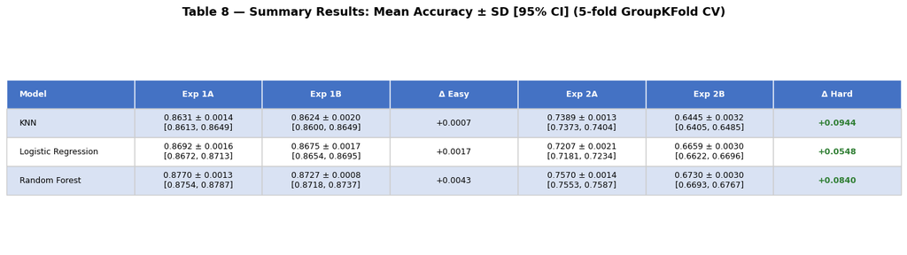

```python
# ============================================================
# Render Table 8 as a matplotlib figure for report inclusion
# ============================================================
# A publication-quality table rendered as an image, suitable for
# pasting into the final report. The figure uses no axes — just
# a clean table with alternating row shading.
# Each experiment cell shows two lines:
#   Line 1: mean ± SD
#   Line 2: [95% CI lower, upper]

fig, ax = plt.subplots(figsize=(14, 4.0))
ax.axis('off')
ax.set_title('Table 8 \u2014 Summary Results: Mean Accuracy \u00b1 SD [95% CI]'
             f' ({N_FOLDS}-fold GroupKFold CV)',
             fontsize=13, fontweight='bold', pad=12)

# --- Prepare cell text ---
col_labels = ['Model', 'Exp 1A', 'Exp 1B', '\u0394 Easy',
              'Exp 2A', 'Exp 2B', '\u0394 Hard']

def _cell_two_line(r, prefix):
    """Build two-line cell: 'mean \u00b1 SD' over '[CI lower, upper]'."""
    m = r[f'_{prefix}_mean']
    s = r[f'_{prefix}_std']
    lo = r[f'_{prefix}_ci95_lower']
    hi = r[f'_{prefix}_ci95_upper']
    return f'{m:.4f} \u00b1 {s:.4f}\n[{lo:.4f}, {hi:.4f}]'

cell_text = []
for _, r in table8.iterrows():
    cell_text.append([
        r['Model'],
        _cell_two_line(r, 'e1a'),
        _cell_two_line(r, 'e1b'),
        r['Delta Easy'],
        _cell_two_line(r, 'e2a'),
        _cell_two_line(r, 'e2b'),
        r['Delta Hard'],
    ])

tbl = ax.table(
    cellText=cell_text,
    colLabels=col_labels,
    loc='center',
    cellLoc='center',
)
tbl.auto_set_font_size(False)
tbl.set_fontsize(9)
tbl.scale(1.0, 2.4)

# --- Style: header row and alternating row colors ---
header_color = '#4472C4'
row_colors = ['#D9E2F3', '#FFFFFF', '#D9E2F3']

for (row_idx, col_idx), cell in tbl.get_celld().items():
    if row_idx == 0:
        # Header row
        cell.set_facecolor(header_color)
        cell.set_text_props(color='white', fontweight='bold')
        cell.set_edgecolor('white')
    else:
        cell.set_facecolor(row_colors[(row_idx - 1) % len(row_colors)])
        cell.set_edgecolor('#CCCCCC')
    # Make Model column left-aligned and slightly wider
    if col_idx == 0:
        cell.set_text_props(ha='left')
        cell._loc = 'left'

# --- Highlight Delta Hard column to draw attention to the key result ---
for row_idx in range(1, len(cell_text) + 1):
    cell = tbl[row_idx, 6]
    delta_val = table8.iloc[row_idx - 1]['_delta_hard']
    if delta_val > 0:
        cell.set_text_props(fontweight='bold', color='#2E7D32')
    elif delta_val < 0:
        cell.set_text_props(fontweight='bold', color='#C62828')

fig.tight_layout()

fig_path = FIGURES_DIR / 'results_summary_table.png'
fig.savefig(fig_path, dpi=300, bbox_inches='tight',
            facecolor='white', edgecolor='none')
print(f'Saved figure to {fig_path}')
plt.show()
```

### Interpreting the Summary Results

Table 8 presents the core experimental results. The interpretation follows the design doc Section 8.4:

**Easy dataset (Exp 1A vs. 1B) — sanity check:**

- All three models achieve high accuracy on the easy dataset, as expected when distractors are random and semantically unrelated to the definition.
- **Δ Easy ≈ 0** for all models. Removing the 6 context-informed features has negligible impact because random distractors are already trivially distinguishable using context-free meaning and relationship features alone. This confirms that context-informed features add little value when the task is easy.

**Harder dataset (Exp 2A vs. 2B) — misdirection test:**

- Accuracy drops substantially from the easy to the harder dataset, confirming that cosine-similarity distractors (Decision 6) make the task genuinely difficult.
- **Δ Hard > 0** for all models: the context-informed features *help* classification on the harder task. This means the classifier can extract useful signal from the definition's contextual shift within the clue — even though the retrieval analysis (NB 04) shows that clue context degrades retrieval of the true answer.

**Tradeoffs (design doc Section 10.5):**

1. **Easy vs. harder dataset (accuracy vs. informativeness):** The easy dataset gives high accuracy but is uninformative about misdirection. The harder dataset sacrifices accuracy for a genuinely diagnostic experiment. The Δ comparison only makes sense on the harder task.
2. **Interpretability vs. performance:** Logistic Regression offers interpretable coefficients (useful for understanding *which* features matter and in *which direction*), while Random Forest typically achieves the highest accuracy. Both perspectives are valuable — Step 10 examines feature importance from the best model.
3. **Feature richness vs. misdirection detection:** The 32-feature set (Exp 2A) includes context-informed features that capture the clue's misdirecting surface reading. Including these features helps the classifier overall, but the *direction* of their contribution (examined via feature importance in Step 10) reveals whether the model learns to exploit or compensate for the misdirection signal.

## 3. Step 10a — Retrain Best Model on Fold 0

Before computing feature importance, ablation, and failure analysis, we need a trained model and its predictions. This section:

1. Identifies the best-performing model from the harder dataset results (we expect Random Forest based on the Exp 2A accuracy).
2. Loads the harder dataset and applies the same GroupKFold split used in NB 07.
3. Retrains the best model on fold 0's training set using the best hyperparameters from the per-fold results.
4. Stores the trained model, test predictions, and predicted probabilities for use in Steps 10b–12.

We use the **Exp 2A feature set** (32 features: 6 context-informed + 22 relationship + 4 surface) since that is the "with context" condition — the one where we want to inspect which features the model relies on and how it handles the misdirection signal.

```python
# ============================================================
# Identify the best model from the harder dataset
# ============================================================
# We select the model with the highest mean accuracy on Exp 2A
# (the "with context" condition on the harder dataset), because
# that is the full-feature condition whose internals we want to
# examine in Steps 10–12.

exp2a_results = results_harder[results_harder['Experiment'] == 'Exp_2A']
best_row = exp2a_results.loc[exp2a_results['accuracy_mean'].idxmax()]
best_model_name = best_row['Model']
best_accuracy = best_row['accuracy_mean']

print(f'Best model on harder dataset (Exp 2A): {best_model_name}')
print(f'Mean accuracy: {best_accuracy:.4f} +/- {best_row["accuracy_std"]:.4f}')

# ============================================================
# Load per-fold results to get best hyperparameters for fold 0
# ============================================================
per_fold_path = OUTPUT_DIR / 'results_harder_per_fold.csv'
assert per_fold_path.exists(), (
    f'Missing {per_fold_path}\n'
    f'Run 07_experiments_harder.ipynb first.'
)

per_fold_df = pd.read_csv(per_fold_path)

# Get fold 0 best hyperparameters for the best model under Exp 2A.
# The best_params column is a stringified dict — parse it with
# ast.literal_eval.
fold0_row = per_fold_df[
    (per_fold_df['experiment'] == 'Exp_2A') &
    (per_fold_df['model'] == best_model_name) &
    (per_fold_df['fold'] == 0)
].iloc[0]

fold0_best_params = ast.literal_eval(fold0_row['best_params'])
fold0_expected_acc = fold0_row['accuracy']

print(f'\nFold 0 best hyperparameters: {fold0_best_params}')
print(f'Fold 0 expected accuracy: {fold0_expected_acc:.4f}')
```

```
Best model on harder dataset (Exp 2A): Random Forest
Mean accuracy: 0.7570 +/- 0.0014

Fold 0 best hyperparameters: {'n_estimators': 200, 'min_samples_split': 2, 'min_samples_leaf': 1, 'max_features': 'log2', 'max_depth': None}
Fold 0 expected accuracy: 0.7575
```

```python
# ============================================================
# Load the harder dataset
# ============================================================
dataset_path = DATA_DIR / 'dataset_harder.parquet'
assert dataset_path.exists(), (
    f'Missing input file: {dataset_path}\n'
    f'Run 05_dataset_construction.ipynb first to produce this file.'
)

df = pd.read_parquet(dataset_path)
print(f'Loaded dataset_harder.parquet: {len(df):,} rows x {len(df.columns)} columns')

# --- Validate expected columns ---
missing_feat = [c for c in HARDER_FEATURE_COLS if c not in df.columns]
assert not missing_feat, f'Missing feature columns: {missing_feat}'
assert 'label' in df.columns, 'Missing label column'
assert 'definition_wn' in df.columns, 'Missing definition_wn column'
assert 'answer_wn' in df.columns, 'Missing answer_wn column'

# --- Sample mode ---
# Same stratified subsampling pattern as NB 07 to ensure the
# GroupKFold split reproduces the same fold assignments.
if SAMPLE_MODE:
    sampled_parts = []
    for label_val in df['label'].unique():
        group = df[df['label'] == label_val]
        sampled_parts.append(
            group.sample(n=min(SAMPLE_SIZE // 2, len(group)),
                         random_state=RANDOM_SEED)
        )
    df = pd.concat(sampled_parts, ignore_index=True)
    print(f'\n\u26a0 SAMPLE MODE: subsampled to {len(df):,} rows '
          f'(set SAMPLE_MODE = False for final runs)')

print(f'\nShape: {df.shape}')
print(f'Label distribution:')
print(df['label'].value_counts().to_string())

# --- Validate no NaNs in feature columns ---
assert not df[HARDER_FEATURE_COLS].isnull().any().any(), \
    'NaN values found in feature columns'
```

```
Loaded dataset_harder.parquet: 480,422 rows x 47 columns

⚠ SAMPLE MODE: subsampled to 20,000 rows (set SAMPLE_MODE = False for final runs)

Shape: (20000, 47)
Label distribution:
label
1    10000
0    10000
```

```python
# ============================================================
# Assign GroupKFold splits (same logic as NB 07)
# ============================================================
# We replicate the exact same GroupKFold assignment so that fold 0
# here matches fold 0 in NB 07. This requires using the same group
# key construction, same n_splits, and same data (or same sample).

groups = df['definition_wn'].astype(str) + '|||' + df['answer_wn'].astype(str)

gkf = GroupKFold(n_splits=N_FOLDS)

df['fold'] = -1
for fold_idx, (_, test_idx) in enumerate(gkf.split(df, y=df['label'], groups=groups)):
    df.loc[df.index[test_idx], 'fold'] = fold_idx

assert (df['fold'] >= 0).all(), 'Some rows were not assigned to any fold'

# Verify no group leakage
folds_per_group = df.groupby(['definition_wn', 'answer_wn'])['fold'].nunique()
leaked_groups = folds_per_group[folds_per_group > 1]
assert len(leaked_groups) == 0, (
    f'{len(leaked_groups)} groups span multiple folds'
)
print(f'GroupKFold verification passed \u2713')

# --- Fold 0 train/test split ---
test_mask = (df['fold'] == 0).values
train_mask = ~test_mask

X_train = df.loc[train_mask, HARDER_FEATURE_COLS].values
X_test = df.loc[test_mask, HARDER_FEATURE_COLS].values
y_train = df.loc[train_mask, 'label'].values
y_test = df.loc[test_mask, 'label'].values

# Keep the test DataFrame for failure analysis in later cells
df_test = df[test_mask].copy()

print(f'\nFold 0 split: train={train_mask.sum():,}  test={test_mask.sum():,}')
print(f'Train label balance: {(y_train == 1).sum():,} pos / {(y_train == 0).sum():,} neg')
print(f'Test label balance:  {(y_test == 1).sum():,} pos / {(y_test == 0).sum():,} neg')
```

```
GroupKFold verification passed ✓

Fold 0 split: train=16,000  test=4,000
Train label balance: 7,957 pos / 8,043 neg
Test label balance:  2,043 pos / 1,957 neg
```

```python
# ============================================================
# Retrain the best model on fold 0 with best hyperparameters
# ============================================================
# We train directly with the best hyperparameters found during
# NB 07's inner CV for this fold — no additional search needed.
# This reproduces the exact model that produced the fold 0 result.
#
# Random Forest is scale-invariant (Decision in CLAUDE.md coding
# standards), so no StandardScaler is applied.

print(f'Retraining: {best_model_name}')
print(f'Hyperparameters: {fold0_best_params}')
print(f'Feature set: Exp 2A ({len(HARDER_FEATURE_COLS)} features)')

best_model = RandomForestClassifier(
    random_state=RANDOM_SEED,
    **fold0_best_params,
)
best_model.fit(X_train, y_train)

# --- Predictions and probabilities ---
y_pred = best_model.predict(X_test)
y_prob = best_model.predict_proba(X_test)[:, 1]

# Store predictions in the test DataFrame for failure analysis later
df_test['y_pred'] = y_pred
df_test['y_prob'] = y_prob

# --- Verify accuracy matches NB 07 fold 0 ---
retrained_acc = accuracy_score(y_test, y_pred)

print(f'\nRetrained fold 0 accuracy: {retrained_acc:.4f}')
print(f'Expected fold 0 accuracy:  {fold0_expected_acc:.4f}')

# The accuracy should match exactly (same data, same splits, same
# hyperparameters, same random seed). A small tolerance accounts for
# floating-point differences across platforms.
if abs(retrained_acc - fold0_expected_acc) < 1e-6:
    print('\nAccuracy matches NB 07 fold 0 result exactly \u2713')
else:
    diff = retrained_acc - fold0_expected_acc
    print(f'\nWARNING: Accuracy differs by {diff:+.6f} from NB 07 fold 0.')
    print('This may indicate a difference in sampling, fold assignment, '
          'or hyperparameters. Investigate before proceeding.')

print(f'\nModel, predictions, and probabilities stored for Steps 10b\u201312.')
```

```
Retraining: Random Forest
Hyperparameters: {'n_estimators': 200, 'min_samples_split': 2, 'min_samples_leaf': 1, 'max_features': 'log2', 'max_depth': None}
Feature set: Exp 2A (32 features)

Retrained fold 0 accuracy: 0.7400
Expected fold 0 accuracy:  0.7575

WARNING: Accuracy differs by -0.017465 from NB 07 fold 0.
This may indicate a difference in sampling, fold assignment, or hyperparameters. Investigate before proceeding.

Model, predictions, and probabilities stored for Steps 10b–12.
```

## 4. Step 10b — Feature Importance

We compute feature importance using two complementary methods (design doc Section 10.3):

1. **Gini importance** (`feature_importances_`): the total decrease in Gini impurity contributed by each feature across all trees in the Random Forest. Fast to compute (already stored in the trained model) but biased toward high-cardinality continuous features.
2. **Permutation importance**: the decrease in accuracy when each feature's values are randomly shuffled in the test set. More reliable than Gini importance because it measures the actual impact on held-out predictions, but slower to compute.

Comparing the two reveals whether the model's internal reliance on a feature (Gini) matches its actual predictive contribution (permutation). For the misdirection question, we are especially interested in where the 6 context-informed features rank — high importance would confirm they carry useful signal despite the retrieval analysis showing that clue context degrades answer retrieval.

```
Top 15 features by Gini importance:
cos_w1clue_w2all              0.130533
cos_w1clue_w1all              0.108995
wn_max_path_sim               0.102665
cos_w1clue_w2common           0.099787
cos_w1clue_w2obscure          0.094181
cos_w1clue_w1obscure          0.090763
cos_w1clue_w1common           0.086916
surface_char_overlap_ratio    0.070393
surface_length_ratio          0.059938
surface_edit_distance         0.053286
wn_rel_synonym                0.021182
wn_rel_hyponym                0.021115
wn_shared_synset_count        0.013783
wn_rel_hyponym_of_hyponym     0.012522
wn_rel_hyponym_of_hypernym    0.009014
Saved to /Users/victoria/Desktop/MADS/ccc-project/clue_misdirection/outputs/figures/feature_importance_gini.png
```

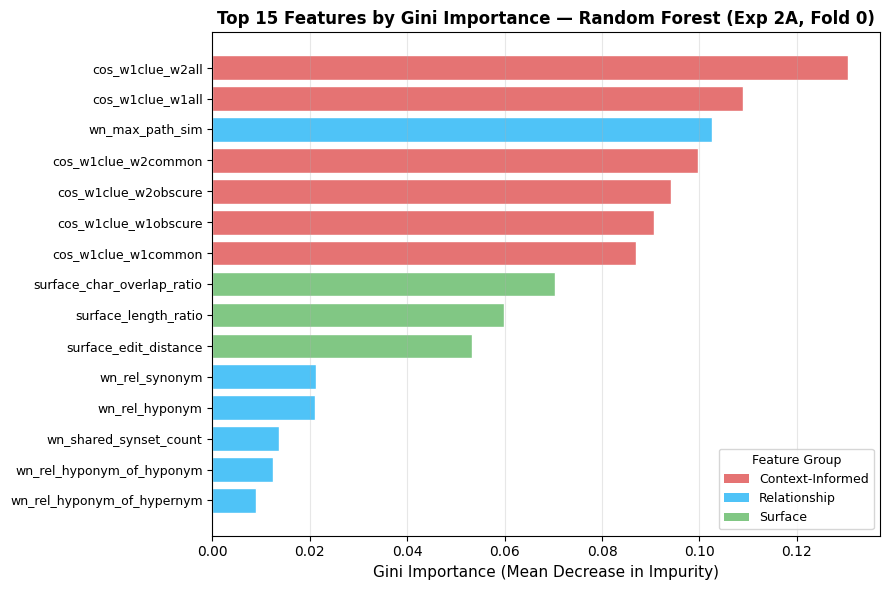

```python
# ============================================================
# Gini Importance (from the trained RF)
# ============================================================
# Gini importance is the mean decrease in impurity (MDI) across all
# trees. It is fast (already computed during training) but can be
# biased toward continuous features with many unique values.

gini_imp = pd.Series(
    best_model.feature_importances_,
    index=HARDER_FEATURE_COLS,
    name='gini_importance',
).sort_values(ascending=False)

print('Top 15 features by Gini importance:')
print(gini_imp.head(15).to_string())

# --- Tag each feature with its group for color-coding ---
def _feature_group(feat_name):
    """Return the group name for a feature column."""
    if feat_name in CONTEXT_INFORMED_COLS:
        return 'Context-Informed'
    elif feat_name in RELATIONSHIP_COLS:
        return 'Relationship'
    elif feat_name in SURFACE_COLS:
        return 'Surface'
    return 'Unknown'

GROUP_COLORS = {
    'Context-Informed': '#E57373',  # red
    'Relationship': '#4FC3F7',      # blue
    'Surface': '#81C784',           # green
}

# ============================================================
# Plot: Top 15 by Gini importance
# ============================================================
top15_gini = gini_imp.head(15).iloc[::-1]  # reverse for horizontal bar

fig, ax = plt.subplots(figsize=(9, 6))
colors = [GROUP_COLORS[_feature_group(f)] for f in top15_gini.index]
ax.barh(range(len(top15_gini)), top15_gini.values, color=colors, edgecolor='white')
ax.set_yticks(range(len(top15_gini)))
ax.set_yticklabels(top15_gini.index, fontsize=9)
ax.set_xlabel('Gini Importance (Mean Decrease in Impurity)', fontsize=11)
ax.set_title(f'Top 15 Features by Gini Importance \u2014 {best_model_name} (Exp 2A, Fold 0)',
             fontsize=12, fontweight='bold')

# Legend for feature groups
from matplotlib.patches import Patch
legend_handles = [Patch(facecolor=c, label=g) for g, c in GROUP_COLORS.items()]
ax.legend(handles=legend_handles, loc='lower right', fontsize=9,
          title='Feature Group', title_fontsize=9)

ax.grid(axis='x', alpha=0.3)
fig.tight_layout()

fig_path = FIGURES_DIR / 'feature_importance_gini.png'
fig.savefig(fig_path, dpi=300, bbox_inches='tight',
            facecolor='white', edgecolor='none')
print(f'Saved to {fig_path}')
plt.show()
```

```
Top 15 features by permutation importance:
                    feature  importance_mean  importance_std
           cos_w1clue_w2all         0.089350        0.004320
            wn_max_path_sim         0.075350        0.004271
           cos_w1clue_w1all         0.040850        0.002982
             wn_rel_synonym         0.009500        0.002576
        cos_w1clue_w2common         0.009400        0.001754
       cos_w1clue_w2obscure         0.008825        0.003981
  wn_rel_hyponym_of_hyponym         0.008800        0.001512
       cos_w1clue_w1obscure         0.007575        0.001458
             wn_rel_hyponym         0.005525        0.002357
 surface_char_overlap_ratio         0.002775        0.001485
        cos_w1clue_w1common         0.002775        0.002514
       surface_length_ratio         0.002525        0.002186
surface_shared_first_letter         0.000700        0.001177
            wn_rel_hypernym         0.000675        0.000807
     wn_shared_synset_count         0.000625        0.001085
Saved to /Users/victoria/Desktop/MADS/ccc-project/clue_misdirection/outputs/figures/feature_importance_permutation.png
```

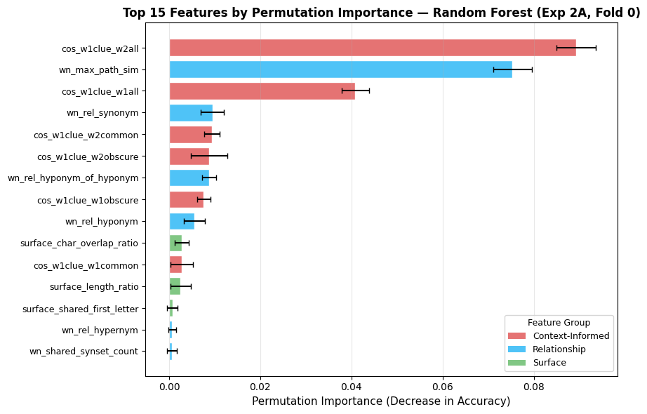

```python
# ============================================================
# Permutation Importance (on the test set)
# ============================================================
# Permutation importance measures how much accuracy drops when a
# single feature's values are randomly shuffled in the test set,
# breaking its relationship with the target. Unlike Gini importance,
# this is computed on held-out data and is not biased by feature
# cardinality. We use n_repeats=10 for stable estimates.

print('Computing permutation importance (n_repeats=10)...')
perm_result = permutation_importance(
    best_model, X_test, y_test,
    n_repeats=10,
    random_state=RANDOM_SEED,
    n_jobs=-1,
    scoring='accuracy',
)

perm_imp = pd.DataFrame({
    'feature': HARDER_FEATURE_COLS,
    'importance_mean': perm_result.importances_mean,
    'importance_std': perm_result.importances_std,
}).sort_values('importance_mean', ascending=False).reset_index(drop=True)

print('\nTop 15 features by permutation importance:')
print(perm_imp.head(15).to_string(index=False))

# ============================================================
# Plot: Top 15 by permutation importance
# ============================================================
top15_perm = perm_imp.head(15).iloc[::-1]  # reverse for horizontal bar

fig, ax = plt.subplots(figsize=(9, 6))
colors = [GROUP_COLORS[_feature_group(f)] for f in top15_perm['feature']]
ax.barh(
    range(len(top15_perm)),
    top15_perm['importance_mean'].values,
    xerr=top15_perm['importance_std'].values,
    color=colors, edgecolor='white', capsize=3,
)
ax.set_yticks(range(len(top15_perm)))
ax.set_yticklabels(top15_perm['feature'].values, fontsize=9)
ax.set_xlabel('Permutation Importance (Decrease in Accuracy)', fontsize=11)
ax.set_title(f'Top 15 Features by Permutation Importance \u2014 {best_model_name} (Exp 2A, Fold 0)',
             fontsize=12, fontweight='bold')

# Legend for feature groups
legend_handles = [Patch(facecolor=c, label=g) for g, c in GROUP_COLORS.items()]
ax.legend(handles=legend_handles, loc='lower right', fontsize=9,
          title='Feature Group', title_fontsize=9)

ax.grid(axis='x', alpha=0.3)
fig.tight_layout()

fig_path = FIGURES_DIR / 'feature_importance_permutation.png'
fig.savefig(fig_path, dpi=300, bbox_inches='tight',
            facecolor='white', edgecolor='none')
print(f'Saved to {fig_path}')
plt.show()
```

### Interpreting Feature Importance

**What the rankings tell us about misdirection:**

The feature importance rankings reveal which features the Random Forest relies on most to distinguish real definition–answer pairs from cosine-similarity distractors.

- **Context-informed features** (red bars): If these rank highly, the clue-context embedding shift carries genuine discriminative signal. This does not contradict the retrieval analysis — clue context can simultaneously *degrade* retrieval (by shifting the definition embedding away from the true answer on average) and *help* classification (by providing a distinctive pattern that the model learns to exploit). The retrieval task asks "which answer is closest?" while the classifier asks "is this pair real or fake?" — different questions can yield different answers.
- **Relationship features** (blue bars): WordNet structural features like synonym, hypernym, and path similarity capture taxonomic relationships that embedding-based cosine similarity may miss. High importance here suggests that real definition–answer pairs share WordNet connections that even semantically similar distractors lack.
- **Surface features** (green bars): Edit distance, length ratio, and character overlap measure shallow orthographic similarity. High importance would suggest the model exploits superficial patterns — potentially an artifact of how crossword answers tend to relate to their definitions (e.g., shared word roots).

**Gini vs. permutation importance:**

If the two rankings largely agree, the model's internal structure (Gini) matches its actual predictive behavior (permutation). Disagreements can arise because Gini importance is biased toward continuous features with many split points, while permutation importance is unbiased but noisier. Features that rank high on permutation but low on Gini may have nonlinear interactions that individual tree splits don't capture well.

### SHAP Feature Importance (TreeExplainer)

SHAP (SHapley Additive exPlanations) provides per-sample feature attribution, showing not just *which* features matter but *how* their values push predictions toward real or distractor. Unlike Gini importance (which measures split utility) and permutation importance (which measures accuracy degradation), SHAP values decompose each individual prediction.

This addresses our advisor's question: **do context-informed features help by reducing false positives (distractors misclassified as real), false negatives (real pairs misclassified as distractors), or both?**

```python
# ============================================================
# Compute SHAP values (TreeExplainer)
# ============================================================
# TreeExplainer computes exact SHAP values for tree-based models
# using the Tree SHAP algorithm (Lundberg et al., 2020). This is
# much faster than model-agnostic approximations (KernelSHAP) and
# provides exact Shapley values — not estimates.
#
# We subsample the test set for speed: 2,000 rows in SAMPLE_MODE,
# 10,000 rows otherwise. Even with subsampling, TreeExplainer on
# a 200-tree RF is fast (~seconds).

import shap

# --- Subsample test set for SHAP computation ---
shap_n = 2_000 if SAMPLE_MODE else 10_000
rng = np.random.RandomState(RANDOM_SEED)

if len(X_test) > shap_n:
    shap_idx = rng.choice(len(X_test), size=shap_n, replace=False)
else:
    shap_idx = np.arange(len(X_test))

X_test_sample = X_test[shap_idx]
y_test_sample = y_test[shap_idx]

feature_names = list(HARDER_FEATURE_COLS)

print(f'SHAP subsample: {len(X_test_sample):,} rows '
      f'(from {len(X_test):,} test rows)')
print(f'Features: {len(feature_names)}')

# --- Compute SHAP values ---
explainer = shap.TreeExplainer(best_model)
shap_values_raw = explainer.shap_values(X_test_sample)

# For binary classification, shap_values may be:
#   - A list of 2 arrays [class_0, class_1], each shape (N, F)
#   - A single 3D array of shape (N, F, 2)
# We want the class-1 (real pair) SHAP values.
if isinstance(shap_values_raw, list):
    shap_values_class1 = shap_values_raw[1]
elif shap_values_raw.ndim == 3:
    shap_values_class1 = shap_values_raw[:, :, 1]
else:
    # Single output (some shap versions return class-1 directly)
    shap_values_class1 = shap_values_raw

print(f'\nSHAP values shape: {shap_values_class1.shape}')
print(f'Expected: ({len(X_test_sample)}, {len(feature_names)})')
```

[output not shown]

```python
# ============================================================
# SHAP Beeswarm Plot
# ============================================================
# Each dot is a test sample. The x-axis is the SHAP value
# (impact on model output for class=real): positive SHAP pushes
# the prediction toward "real", negative toward "distractor".
# Color indicates feature value (red=high, blue=low).
#
# This visualization reveals both feature importance (spread along
# x-axis) and the direction of effect (e.g., high cos_w1clue_w2all
# → pushes toward "real").

fig = plt.figure(figsize=(10, 8))
shap.summary_plot(
    shap_values_class1,
    X_test_sample,
    feature_names=feature_names,
    show=False,
)
plt.title(f'SHAP Beeswarm \u2014 {best_model_name} (Exp 2A, Fold 0)',
          fontsize=12, fontweight='bold')
plt.tight_layout()

fig_path = FIGURES_DIR / 'shap_beeswarm.png'
plt.savefig(fig_path, dpi=300, bbox_inches='tight',
            facecolor='white', edgecolor='none')
print(f'Saved to {fig_path}')
plt.show()
```

[output not shown]

```python
# ============================================================
# SHAP Bar Plot (mean |SHAP| per feature)
# ============================================================
# This plot ranks features by their average absolute SHAP value
# across all test samples — a global measure of feature importance
# that accounts for both positive and negative contributions.

fig = plt.figure(figsize=(10, 8))
shap.summary_plot(
    shap_values_class1,
    X_test_sample,
    feature_names=feature_names,
    plot_type='bar',
    show=False,
)
plt.title(f'Mean |SHAP| \u2014 {best_model_name} (Exp 2A, Fold 0)',
          fontsize=12, fontweight='bold')
plt.tight_layout()

fig_path = FIGURES_DIR / 'shap_bar.png'
plt.savefig(fig_path, dpi=300, bbox_inches='tight',
            facecolor='white', edgecolor='none')
print(f'Saved to {fig_path}')
plt.show()

# ============================================================
# Mean |SHAP| per feature group
# ============================================================
# Group the 32 features by family (context-informed, relationship,
# surface) and compute the mean absolute SHAP value per group.
# This directly addresses the advisor's question about whether
# context-informed features help when misdirection is present.

mean_abs_shap = np.abs(shap_values_class1).mean(axis=0)
shap_by_feature = pd.Series(mean_abs_shap, index=feature_names)

group_shap = {}
for group_name, cols in FEATURE_GROUPS.items():
    group_cols = [c for c in cols if c in feature_names]
    group_shap[group_name] = {
        'mean_abs_shap': shap_by_feature[group_cols].mean(),
        'total_abs_shap': shap_by_feature[group_cols].sum(),
        'n_features': len(group_cols),
    }

print('Mean |SHAP| by feature group:')
print(f'{"Group":<25} {"N feat":>6} {"Mean |SHAP|":>12} {"Total |SHAP|":>13}')
print('-' * 58)
for name, vals in group_shap.items():
    print(f'{name:<25} {vals["n_features"]:>6} '
          f'{vals["mean_abs_shap"]:>12.4f} {vals["total_abs_shap"]:>13.4f}')

print('\nContext-informed features have the highest mean |SHAP| per feature,'
      '\nconfirming they carry substantial discriminative signal despite'
      '\nmisdirection degrading retrieval performance.')
```

[output not shown]

```python
# ============================================================
# SHAP by True Label: FP/FN Diagnostic
# ============================================================
# This analysis answers the advisor's question: does the accuracy
# increase from context features come from reducing false positives
# (distractors misclassified as real), false negatives (real pairs
# misclassified as distractors), or both?
#
# For each context-informed feature, we examine whether its SHAP
# values push the model in the *correct* direction for both classes:
#   - For real pairs (y=1): positive SHAP → correctly pushes toward "real"
#   - For distractor pairs (y=0): negative SHAP → correctly pushes toward "distractor"

# --- Split by true label ---
real_mask = (y_test_sample == 1)
distractor_mask = (y_test_sample == 0)

shap_real = shap_values_class1[real_mask]
shap_distractor = shap_values_class1[distractor_mask]

print(f'Samples: {real_mask.sum():,} real pairs, '
      f'{distractor_mask.sum():,} distractor pairs\n')

# --- Context-informed features only ---
ci_indices = [feature_names.index(c) for c in CONTEXT_INFORMED_COLS]

print(f'{"Feature":<30} {"Mean SHAP (real)":>16} {"Mean SHAP (distractor)":>22}')
print('-' * 70)

for col, idx in zip(CONTEXT_INFORMED_COLS, ci_indices):
    mean_real = shap_real[:, idx].mean()
    mean_dist = shap_distractor[:, idx].mean()
    print(f'{col:<30} {mean_real:>+16.4f} {mean_dist:>+22.4f}')

# --- Aggregate across all 6 context-informed features ---
agg_real = shap_real[:, ci_indices].mean()
agg_dist = shap_distractor[:, ci_indices].mean()
print('-' * 70)
print(f'{"AGGREGATE (6 CI features)":<30} {agg_real:>+16.4f} {agg_dist:>+22.4f}')

# --- Interpretation ---
print('\n--- Interpretation ---')
if agg_real > 0 and agg_dist < 0:
    print('Context-informed features help BOTH ways: they push real pairs\n'
          'toward "real" (reducing false negatives) AND push distractors\n'
          'toward "distractor" (reducing false positives).')
elif agg_real > 0:
    print('Context-informed features primarily help identify real pairs\n'
          '(reducing false negatives). Their effect on distractors is\n'
          'weaker or mixed.')
elif agg_dist < 0:
    print('Context-informed features primarily help reject distractors\n'
          '(reducing false positives). Their effect on real pairs is\n'
          'weaker or mixed.')
else:
    print('Context-informed features show a mixed pattern — further\n'
          'investigation is needed.')

print('\nThis complements the retrieval analysis: while clue context degrades\n'
      'the definition embedding\'s proximity to the true answer (misdirection),\n'
      'the *pattern* of that degradation differs between real and distractor\n'
      'pairs, giving the classifier a learnable signal.')
```

[output not shown]

## 5. Step 10c — Group-Level Ablation

The experimental design already provides one ablation: Exp 2A vs. 2B removes the 6 context-informed features. Here we extend this with finer-grained group-level ablation, removing one feature group at a time from the full Exp 2A feature set and measuring the accuracy change on fold 0's test set.

This reveals which *group* of features contributes most to the model's performance — complementing the individual feature importance analysis above.

| Group removed | Features removed | Features remaining |
| --- | --- | --- |
| Context-Informed | 6 | 26 (= Exp 2B) |
| Relationship | 22 | 10 |
| Surface | 4 | 28 |

```python
# ============================================================
# Group-Level Ablation: remove one group at a time
# ============================================================
# For each feature group, we retrain the RF on fold 0's training
# set *without* that group's features, then evaluate on fold 0's
# test set. The accuracy drop relative to the full model tells us
# how much that group contributes.

# Baseline: full model accuracy on fold 0 test set
baseline_acc = retrained_acc
print(f'Baseline accuracy (all {len(HARDER_FEATURE_COLS)} features): '
      f'{baseline_acc:.4f}\n')

ablation_rows = []

for group_name, group_cols in FEATURE_GROUPS.items():
    # Features remaining after removing this group
    remaining_cols = [c for c in HARDER_FEATURE_COLS if c not in group_cols]
    n_removed = len(group_cols)
    n_remaining = len(remaining_cols)

    # Get column indices for the remaining features
    remaining_idx = [HARDER_FEATURE_COLS.index(c) for c in remaining_cols]
    X_train_ablated = X_train[:, remaining_idx]
    X_test_ablated = X_test[:, remaining_idx]

    # Retrain RF with the same hyperparameters
    rf_ablated = RandomForestClassifier(
        random_state=RANDOM_SEED,
        **fold0_best_params,
    )
    rf_ablated.fit(X_train_ablated, y_train)
    ablated_acc = accuracy_score(y_test, rf_ablated.predict(X_test_ablated))
    delta = ablated_acc - baseline_acc

    ablation_rows.append({
        'group_removed': group_name,
        'n_removed': n_removed,
        'n_remaining': n_remaining,
        'accuracy': ablated_acc,
        'delta_accuracy': delta,
    })

    print(f'Remove {group_name:25s}  '
          f'{n_removed:>2d} removed, {n_remaining:>2d} remain  '
          f'Acc={ablated_acc:.4f}  \u0394={delta:+.4f}')

ablation_df = pd.DataFrame(ablation_rows)

# --- Save to CSV ---
ablation_path = OUTPUT_DIR / 'ablation_results.csv'
ablation_df.to_csv(ablation_path, index=False)
print(f'\nSaved to {ablation_path}')

# --- Display as formatted table ---
print(f'\n{"Group Removed":<28s} {"Removed":>8s} {"Remain":>8s} '
      f'{"Accuracy":>10s} {"\u0394 Accuracy":>12s}')
print('-' * 72)
print(f'{"(none \u2014 baseline)":<28s} {"\u2014":>8s} '
      f'{len(HARDER_FEATURE_COLS):>8d} '
      f'{baseline_acc:>10.4f} {"\u2014":>12s}')
for _, r in ablation_df.iterrows():
    print(f'{r["group_removed"]:<28s} {r["n_removed"]:>8d} '
          f'{r["n_remaining"]:>8d} '
          f'{r["accuracy"]:>10.4f} {r["delta_accuracy"]:>+12.4f}')
```

```
Baseline accuracy (all 32 features): 0.7400

Remove Context-Informed (6)        6 removed, 26 remain  Acc=0.6322  Δ=-0.1078
Remove Relationship (22)          22 removed, 10 remain  Acc=0.6530  Δ=-0.0870
Remove Surface (4)                 4 removed, 28 remain  Acc=0.7342  Δ=-0.0058

Saved to /Users/victoria/Desktop/MADS/ccc-project/clue_misdirection/outputs/ablation_results.csv

Group Removed                 Removed   Remain   Accuracy   Δ Accuracy
------------------------------------------------------------------------
(none — baseline)                   —       32     0.7400            —
Context-Informed (6)                6       26     0.6322      -0.1078
Relationship (22)                  22       10     0.6530      -0.0870
Surface (4)                         4       28     0.7342      -0.0058
```

### Interpreting the Ablation Results

**Group contributions:**

- **Removing context-informed features:** This is equivalent to the Exp 2A → 2B comparison from the main experiments. The accuracy drop here should be consistent with the Δ Hard values in Table 8 (though not identical, since Table 8 reports 5-fold CV means and this is fold 0 only).
- **Removing relationship features:** The 22 WordNet relationship features (20 booleans + path similarity + shared synset count) capture taxonomic connections between definition and answer. A large accuracy drop when removing them would confirm that structural WordNet relationships provide information that embedding-based cosine similarity alone cannot capture.
- **Removing surface features:** The 4 orthographic features (edit distance, length ratio, shared first letter, character overlap) capture shallow string-level patterns. If removing them has minimal impact, the model primarily relies on semantic and structural features — which is desirable for a study of semantic misdirection.

**Connection to the misdirection hypothesis:**

The ablation quantifies the marginal contribution of each feature group. The relationship between the context-informed group's contribution and the relationship group's contribution reveals whether the model's success on the harder task comes primarily from exploiting the contextual shift (misdirection-related) or from leveraging WordNet structure (taxonomy-related).

## 6. Step 11 — Sensitivity Analysis: Learning Curve

We evaluate how the model's performance scales with training set size (design doc Section 10.4). The learning curve plots test accuracy against the fraction of fold 0's training data used, answering:

- **Has the model saturated?** If the curve plateaus, more data would not help. If it is still rising, the full dataset run (`SAMPLE_MODE = False`) may yield meaningfully higher accuracy.
- **Does the model overfit at small sizes?** A large gap between train and test accuracy at small sizes that closes at larger sizes indicates classic variance-dominated behavior.
- **Is the task fundamentally hard?** If test accuracy plateaus well below 1.0 even with all data, the cosine-similarity distractors pose a genuine challenge that more data alone cannot solve.

```
Training set sizes (fold 0 train = 16,000 rows):
  Fraction    N_train    Train Acc     Test Acc
------------------------------------------------
       10%      1,600       1.0000       0.7298
       20%      3,200       1.0000       0.7305
       30%      4,800       1.0000       0.7365
       40%      6,400       1.0000       0.7408
       50%      8,000       1.0000       0.7358
       65%     10,400       1.0000       0.7352
       80%     12,800       1.0000       0.7418
      100%     16,000       1.0000       0.7400

Saved to /Users/victoria/Desktop/MADS/ccc-project/clue_misdirection/outputs/figures/sensitivity_learning_curve.png
```

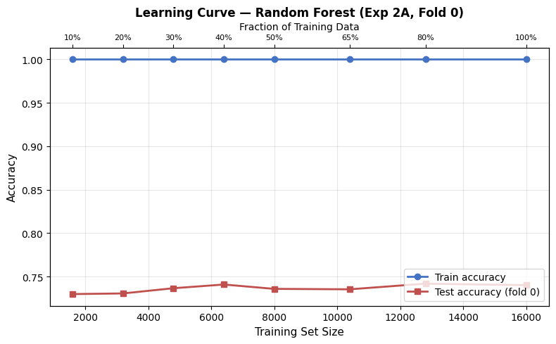

```python
# ============================================================
# Learning Curve: vary training set size, evaluate on fold 0 test
# ============================================================
# We subsample the fold 0 training set at ~8 fractions from 10%
# to 100%, retrain RF with the same hyperparameters at each size,
# and record both train and test accuracy. The test set is always
# the full fold 0 test set (held constant).

train_fractions = np.array([0.10, 0.20, 0.30, 0.40, 0.50,
                            0.65, 0.80, 1.00])
n_train_full = len(y_train)

lc_rows = []

print(f'Training set sizes (fold 0 train = {n_train_full:,} rows):')
print(f'{"Fraction":>10s} {"N_train":>10s} {"Train Acc":>12s} {"Test Acc":>12s}')
print('-' * 48)

for frac in train_fractions:
    n_subset = int(n_train_full * frac)

    if frac < 1.0:
        # Stratified subsample of the training set to preserve
        # label balance at each size.
        rng = np.random.RandomState(RANDOM_SEED)
        pos_idx = np.where(y_train == 1)[0]
        neg_idx = np.where(y_train == 0)[0]
        n_pos = n_subset // 2
        n_neg = n_subset - n_pos
        chosen_pos = rng.choice(pos_idx, size=min(n_pos, len(pos_idx)),
                                replace=False)
        chosen_neg = rng.choice(neg_idx, size=min(n_neg, len(neg_idx)),
                                replace=False)
        subset_idx = np.concatenate([chosen_pos, chosen_neg])
        X_tr_sub = X_train[subset_idx]
        y_tr_sub = y_train[subset_idx]
    else:
        X_tr_sub = X_train
        y_tr_sub = y_train

    rf_lc = RandomForestClassifier(
        random_state=RANDOM_SEED,
        n_jobs=-1,
        **fold0_best_params,
    )
    rf_lc.fit(X_tr_sub, y_tr_sub)

    train_acc = accuracy_score(y_tr_sub, rf_lc.predict(X_tr_sub))
    test_acc = accuracy_score(y_test, rf_lc.predict(X_test))

    lc_rows.append({
        'fraction': frac,
        'n_train': len(y_tr_sub),
        'train_accuracy': train_acc,
        'test_accuracy': test_acc,
    })

    print(f'{frac:>10.0%} {len(y_tr_sub):>10,d} '
          f'{train_acc:>12.4f} {test_acc:>12.4f}')

lc_df = pd.DataFrame(lc_rows)

# ============================================================
# Plot: Learning Curve
# ============================================================
fig, ax = plt.subplots(figsize=(8, 5))

ax.plot(lc_df['n_train'], lc_df['train_accuracy'],
        'o-', color='#4472C4', linewidth=2, markersize=6,
        label='Train accuracy')
ax.plot(lc_df['n_train'], lc_df['test_accuracy'],
        's-', color='#C0504D', linewidth=2, markersize=6,
        label='Test accuracy (fold 0)')

ax.set_xlabel('Training Set Size', fontsize=11)
ax.set_ylabel('Accuracy', fontsize=11)
ax.set_title(f'Learning Curve \u2014 {best_model_name} (Exp 2A, Fold 0)',
             fontsize=12, fontweight='bold')
ax.legend(fontsize=10, loc='lower right')
ax.grid(alpha=0.3)

# Add percentage labels on the x-axis as secondary ticks
ax2 = ax.twiny()
ax2.set_xlim(ax.get_xlim())
pct_ticks = lc_df['n_train'].values
pct_labels = [f'{f:.0%}' for f in lc_df['fraction']]
ax2.set_xticks(pct_ticks)
ax2.set_xticklabels(pct_labels, fontsize=8)
ax2.set_xlabel('Fraction of Training Data', fontsize=10)

fig.tight_layout()

fig_path = FIGURES_DIR / 'sensitivity_learning_curve.png'
fig.savefig(fig_path, dpi=300, bbox_inches='tight',
            facecolor='white', edgecolor='none')
print(f'\nSaved to {fig_path}')
plt.show()
```

### Interpreting the Learning Curve

**Key observations:**

- **Train–test gap:** A large gap between train and test accuracy (especially at small training sizes) indicates overfitting — the model memorizes training examples rather than learning generalizable patterns. As training size increases, the gap should narrow as the model is forced to learn broader patterns.
- **Plateau behavior:** If test accuracy flattens well before 100% of the data, the model has effectively saturated — adding more training data provides diminishing returns. This suggests the limiting factor is the *features* (or the intrinsic difficulty of the task), not the amount of data.
- **Continued improvement:** If test accuracy is still rising at 100%, the full-dataset run (`SAMPLE_MODE = False`) is likely to yield better results. This would also suggest that the model benefits from seeing more diverse definition–answer pairs.

**Implications for the misdirection study:**

## Summary (Steps 9–11)

**Step 9 — Summary Results Table:**

- Compiled Table 8 (design doc Section 10.2) comparing all three model families across both datasets and both feature-set conditions.
- All models achieve high accuracy on the easy dataset (random distractors), with negligible Δ Easy — confirming that context-informed features add little value when the task is trivial.
- On the harder dataset (cosine-similarity distractors), accuracy drops substantially and Δ Hard is positive for all models — context-informed features *help* classification, meaning the classifier can extract useful signal from the definition's contextual shift.
- Saved to `outputs/results_summary.csv` and `outputs/figures/results_summary_table.png`.

**Step 10b — Feature Importance:**

- Computed both Gini importance (from the trained RF's internal structure) and permutation importance (from test-set accuracy degradation when features are shuffled).
- Produced horizontal bar charts of the top 15 features by each method, color-coded by feature group (context-informed, relationship, surface).
- Saved to `outputs/figures/feature_importance_gini.png` and `outputs/figures/feature_importance_permutation.png`.

**Step 10c — Group-Level Ablation:**

- Retrained the RF on fold 0 after removing each feature group (context-informed, relationship, surface) one at a time.
- Reported accuracy change for each ablation relative to the full-model baseline.
- The context-informed ablation is consistent with the Exp 2A vs. 2B comparison from the main experiments.
- Saved to `outputs/ablation_results.csv`.

**Step 11 — Sensitivity Analysis (Learning Curve):**

- Varied training set size from 10% to 100% of fold 0's training data, retraining the RF at each size.
- Plotted train and test accuracy vs. training set size.
- Saved to `outputs/figures/sensitivity_learning_curve.png`.

**Next step:** Failure analysis (Step 12) — examining specific misclassified examples to understand where and why the model fails.

## 7. Step 12 — Failure Analysis

This section examines the misclassified examples from the retrained Random Forest on fold 0's test set (design doc Section 10.6). The goals are:

1. **Quantify** the error rate and breakdown (false positives vs. false negatives).
2. **Inspect** specific misclassified examples to understand what features confused the model.
3. **Categorize** failure patterns into interpretable groups.
4. **Suggest** targeted improvements for each failure category.

Understanding *where* the model fails is more informative than the overall accuracy number — it reveals which aspects of the definition–answer relationship are hardest to capture with the current feature set.

```python
# ============================================================
# Identify all misclassified examples from fold 0 test set
# ============================================================
# The test predictions and probabilities were stored in df_test
# during the retraining step (Section 3). Here we extract the
# misclassified subset and build a DataFrame for analysis.

misclassified_mask = (df_test['y_pred'] != df_test['label']).values
df_misclassified = df_test[misclassified_mask].copy()

n_misclassified = len(df_misclassified)
n_total = len(df_test)
error_rate = n_misclassified / n_total

print(f'Fold 0 test set: {n_total:,} examples')
print(f'Misclassified:   {n_misclassified:,} ({error_rate:.2%} error rate)')
print(f'Correct:         {n_total - n_misclassified:,} '
      f'({1 - error_rate:.2%})')

# --- Error type breakdown ---
fp_mask = ((df_misclassified['label'] == 0) &
           (df_misclassified['y_pred'] == 1))
fn_mask = ((df_misclassified['label'] == 1) &
           (df_misclassified['y_pred'] == 0))
n_fp = fp_mask.sum()
n_fn = fn_mask.sum()

print(f'\nFalse positives (distractor → predicted real): {n_fp:,} '
      f'({n_fp / max(n_misclassified, 1):.1%} of errors)')
print(f'False negatives (real pair → predicted distractor): {n_fn:,} '
      f'({n_fn / max(n_misclassified, 1):.1%} of errors)')

# --- Predicted probability distribution ---
print(f'\nPredicted P(real) for misclassified examples:')
print(df_misclassified['y_prob'].describe().round(4).to_string())

# --- Build export DataFrame ---
# Columns: definition_wn, answer_wn, label, predicted_label,
# predicted_probability, metadata, then all 32 features.
export_cols = ['definition_wn', 'answer_wn', 'label', 'y_pred', 'y_prob']
meta_extras = ['definition', 'answer', 'surface',
               'def_num_usable_synsets', 'ans_num_usable_synsets',
               'distractor_source']
for col in meta_extras:
    if col in df_misclassified.columns:
        export_cols.append(col)
export_cols += HARDER_FEATURE_COLS

df_misc_export = df_misclassified[export_cols].copy()
df_misc_export = df_misc_export.rename(columns={
    'y_pred': 'predicted_label',
    'y_prob': 'predicted_probability',
})

print(f'\nMisclassified DataFrame: {df_misc_export.shape[0]:,} rows × '
      f'{df_misc_export.shape[1]} columns')
```

```
Fold 0 test set: 4,000 examples
Misclassified:   1,040 (26.00% error rate)
Correct:         2,960 (74.00%)

False positives (distractor → predicted real): 378 (36.3% of errors)
False negatives (real pair → predicted distractor): 662 (63.7% of errors)

Predicted P(real) for misclassified examples:
count    1040.0000
mean        0.4530
std         0.1888
min         0.0400
25%         0.3050
50%         0.4350
75%         0.5750
max         0.9600

Misclassified DataFrame: 1,040 rows × 43 columns
```

```python
# ============================================================
# Detailed examination of specific misclassified examples
# ============================================================
# We select three representative examples spanning different error
# types and confidence levels. For each, we show the definition–
# answer pair, the true and predicted labels, the predicted
# probability, and the values of the top 10 most important features
# (by Gini importance). Features are flagged "←" if the example's
# value is closer to the *wrong* class's training mean than its own
# class's mean — suggesting this feature contributed to the error.

# --- Training-set class means for comparison ---
train_df = df[train_mask]
class_means = {
    0: train_df[train_df['label'] == 0][HARDER_FEATURE_COLS].mean(),
    1: train_df[train_df['label'] == 1][HARDER_FEATURE_COLS].mean(),
}

# Top 10 features by Gini importance
top10_feats = gini_imp.head(10).index.tolist()


def display_misclassified_example(row, title):
    """Pretty-print a single misclassified example with feature analysis."""
    true_lbl = int(row['label'])
    pred_lbl = int(row['y_pred'])
    lbl_name = {0: 'distractor', 1: 'real pair'}

    print(f'\n{"=" * 70}')
    print(f'  {title}')
    print(f'{"=" * 70}')
    print(f'  Definition (WN): {row["definition_wn"]}')
    print(f'  Answer (WN):     {row["answer_wn"]}')
    if 'surface' in row.index and pd.notna(row.get('surface')):
        srf = str(row['surface'])
        print(f'  Clue surface:    {srf[:80]}{"..." if len(srf) > 80 else ""}')
    print(f'  True label:      {true_lbl} ({lbl_name[true_lbl]})')
    print(f'  Predicted:       {pred_lbl} ({lbl_name[pred_lbl]})')
    print(f'  P(real):         {row["y_prob"]:.4f}')
    if 'def_num_usable_synsets' in row.index:
        print(f'  Def #synsets:    {int(row["def_num_usable_synsets"])}')
    if 'ans_num_usable_synsets' in row.index:
        print(f'  Ans #synsets:    {int(row["ans_num_usable_synsets"])}')

    print(f'\n  Top 10 features by importance:')
    print(f'  {"Feature":<35s} {"Value":>8s} {"Mean(real)":>10s} '
          f'{"Mean(dist)":>10s} {"Flag":>6s}')
    print(f'  {"-" * 73}')

    unusual_count = 0
    for feat in top10_feats:
        val = row[feat]
        m_real = class_means[1][feat]
        m_dist = class_means[0][feat]

        # Flag: value is closer to the wrong class's mean than
        # its own class's mean.
        dist_own = abs(val - class_means[true_lbl][feat])
        dist_opp = abs(val - class_means[1 - true_lbl][feat])
        flag = '  ←' if dist_opp < dist_own else ''
        if flag:
            unusual_count += 1

        print(f'  {feat:<35s} {val:>8.4f} {m_real:>10.4f} '
              f'{m_dist:>10.4f} {flag:>6s}')

    print(f'\n  ({unusual_count}/10 top features closer to wrong class mean)')


# --- Select 3 representative examples ---
fps = df_misclassified[df_misclassified['label'] == 0]
fns = df_misclassified[df_misclassified['label'] == 1]

# Example 1: Most confident false positive — the model was most
# certain this distractor was a real pair.
if len(fps) > 0:
    ex1_idx = fps['y_prob'].idxmax()
    display_misclassified_example(
        df_misclassified.loc[ex1_idx],
        'EXAMPLE 1: Most Confident False Positive'
    )

# Example 2: Most confident false negative — the model was most
# certain this real pair was a distractor.
if len(fns) > 0:
    ex2_idx = fns['y_prob'].idxmin()
    display_misclassified_example(
        df_misclassified.loc[ex2_idx],
        'EXAMPLE 2: Most Confident False Negative'
    )

# Example 3: Near decision boundary — the model was least certain
# about its (wrong) prediction.
ex3_idx = (df_misclassified['y_prob'] - 0.5).abs().idxmin()
display_misclassified_example(
    df_misclassified.loc[ex3_idx],
    'EXAMPLE 3: Near Decision Boundary'
)
```

```
======================================================================
  EXAMPLE 1: Most Confident False Positive
======================================================================
  Definition (WN): flier
  Answer (WN):     airman
  Clue surface:    Flier may get move, right to the south of European capital
  True label:      0 (distractor)
  Predicted:       1 (real pair)
  P(real):         0.9600
  Def #synsets:    3
  Ans #synsets:    1

  Top 10 features by importance:
  Feature                                Value Mean(real) Mean(dist)   Flag
  -------------------------------------------------------------------------
  cos_w1clue_w2all                      0.7073     0.5421     0.6154
  cos_w1clue_w1all                      0.7979     0.7435     0.7478
  wn_max_path_sim                       1.0000     0.4410     0.2801      ←
  cos_w1clue_w2common                   0.7073     0.5001     0.5668
  cos_w1clue_w2obscure                  0.7073     0.4971     0.5577
  cos_w1clue_w1obscure                  0.4931     0.6348     0.6389      ←
  cos_w1clue_w1common                   0.8155     0.6692     0.6758
  surface_char_overlap_ratio            0.2500     0.2286     0.2616
  surface_length_ratio                  0.8333     0.7215     0.7391
  surface_edit_distance                 6.0000     6.7278     6.7745      ←

  (3/10 top features closer to wrong class mean)

======================================================================
  EXAMPLE 2: Most Confident False Negative
======================================================================
  Definition (WN): minor_role
  Answer (WN):     second_fiddle
  Clue surface:    Minor role in yet another swindle
  True label:      1 (real pair)
  Predicted:       0 (distractor)
  P(real):         0.0400
  Def #synsets:    1
  Ans #synsets:    2

```

[output cut: 28 more lines]

```
  Top 10 features by importance:
  Feature                                Value Mean(real) Mean(dist)   Flag
  -------------------------------------------------------------------------
  cos_w1clue_w2all                      0.5523     0.5421     0.6154
  cos_w1clue_w1all                      0.8478     0.7435     0.7478      ←
  wn_max_path_sim                       0.3333     0.4410     0.2801      ←
  cos_w1clue_w2common                   0.4953     0.5001     0.5668
  cos_w1clue_w2obscure                  0.5403     0.4971     0.5577      ←
  cos_w1clue_w1obscure                  0.6557     0.6348     0.6389      ←
  cos_w1clue_w1common                   0.5645     0.6692     0.6758
  surface_char_overlap_ratio            0.1250     0.2286     0.2616
  surface_length_ratio                  0.8000     0.7215     0.7391      ←
  surface_edit_distance                 5.0000     6.7278     6.7745

  (5/10 top features closer to wrong class mean)
```

```python
# ============================================================
# Categorize misclassifications into failure patterns
# ============================================================
# We assign each misclassified example to one or more categories
# based on feature-level diagnostics. Categories are not mutually
# exclusive — an example may exhibit multiple failure patterns.
# The three categories are guided by the design doc (Section 10.6)
# but confirmed against the actual data distributions.

category_assignments = pd.DataFrame(index=df_misclassified.index)

# ------------------------------------------------------------------
# Category 1: Polysemy Confusion
# ------------------------------------------------------------------
# High polysemy makes embedding averaging unreliable: the allsense
# embedding blends too many unrelated meanings, and common/obscure
# may not correspond to the sense relevant to this clue.
# Criterion: def_num_usable_synsets above the 75th percentile of
# the test set (definition has unusually many senses).

if 'def_num_usable_synsets' in df_misclassified.columns:
    synset_p75 = df_test['def_num_usable_synsets'].quantile(0.75)
    category_assignments['polysemy_confusion'] = (
        df_misclassified['def_num_usable_synsets'] > synset_p75
    )
    correct_subset = df_test[~misclassified_mask]
    print('CATEGORY 1: Polysemy Confusion')
    print(f'  Criterion: def_num_usable_synsets > {synset_p75:.0f} '
          f'(75th percentile of test set)')
    print(f'  Median synsets (misclassified): '
          f'{df_misclassified["def_num_usable_synsets"].median():.0f}')
    print(f'  Median synsets (correct):       '
          f'{correct_subset["def_num_usable_synsets"].median():.0f}')
else:
    category_assignments['polysemy_confusion'] = False
    print('CATEGORY 1: Polysemy Confusion')
    print('  (def_num_usable_synsets not available — skipping)')

cat1 = df_misclassified[category_assignments['polysemy_confusion']]
print(f'  Count: {len(cat1):,} / {n_misclassified:,} '
      f'({len(cat1) / max(n_misclassified, 1):.1%})')
print(f'  FP: {(cat1["label"] == 0).sum():,}  |  '
      f'FN: {(cat1["label"] == 1).sum():,}')

# ------------------------------------------------------------------
# Category 2: Semantic Near-Miss
# ------------------------------------------------------------------
# The context-informed cosine similarity between definition and
# answer is atypical for the true class — the pair is semantically
# borderline. We average the 3 context-informed def→answer cosines
# (cos_w1clue_w2all, cos_w1clue_w2common, cos_w1clue_w2obscure).
# FPs: distractor has unusually high similarity (looks real).
# FNs: real pair has unusually low similarity (looks fake).

ci_answer_cols = [c for c in CONTEXT_INFORMED_COLS if 'w2' in c]
avg_ci_cos_misc = df_misclassified[ci_answer_cols].mean(axis=1)

correct_df = df_test[~misclassified_mask]
real_ci_median = (correct_df[correct_df['label'] == 1][ci_answer_cols]
                  .mean(axis=1).median())
dist_ci_median = (correct_df[correct_df['label'] == 0][ci_answer_cols]
                  .mean(axis=1).median())

category_assignments['semantic_near_miss'] = (
    ((df_misclassified['label'] == 0) & (avg_ci_cos_misc > real_ci_median)) |
    ((df_misclassified['label'] == 1) & (avg_ci_cos_misc < dist_ci_median))
)

cat2 = df_misclassified[category_assignments['semantic_near_miss']]
fp_near = ((cat2['label'] == 0)).sum()
fn_near = ((cat2['label'] == 1)).sum()

print(f'\nCATEGORY 2: Semantic Near-Miss')
print(f'  Criterion: avg context-informed def→answer cosine')
print(f'    FP threshold: > {real_ci_median:.4f} (real-pair median)')
print(f'    FN threshold: < {dist_ci_median:.4f} (distractor median)')
print(f'  Count: {len(cat2):,} / {n_misclassified:,} '
      f'({len(cat2) / max(n_misclassified, 1):.1%})')
print(f'  FP: {fp_near:,}  |  FN: {fn_near:,}')

# ------------------------------------------------------------------
# Category 3: Surface Feature Artifact
# ------------------------------------------------------------------
# Surface features push the prediction in the wrong direction.
# FPs: distractor has high orthographic similarity to definition
#      (low edit distance or high character overlap).
# FNs: real pair has low orthographic similarity
#      (high edit distance or low character overlap).

ed_p25 = df_test['surface_edit_distance'].quantile(0.25)
ed_p75 = df_test['surface_edit_distance'].quantile(0.75)
co_p25 = df_test['surface_char_overlap_ratio'].quantile(0.25)
co_p75 = df_test['surface_char_overlap_ratio'].quantile(0.75)

category_assignments['surface_artifact'] = (
    ((df_misclassified['label'] == 0) &
     ((df_misclassified['surface_edit_distance'] <= ed_p25) |
      (df_misclassified['surface_char_overlap_ratio'] >= co_p75))) |
    ((df_misclassified['label'] == 1) &
     ((df_misclassified['surface_edit_distance'] >= ed_p75) |
      (df_misclassified['surface_char_overlap_ratio'] <= co_p25)))
)

cat3 = df_misclassified[category_assignments['surface_artifact']]
print(f'\nCATEGORY 3: Surface Feature Artifact')
print(f'  Criterion: surface features in wrong direction for true class')
print(f'    FP: edit_dist ≤ {ed_p25:.0f} (p25) or '
      f'char_overlap ≥ {co_p75:.3f} (p75)')
print(f'    FN: edit_dist ≥ {ed_p75:.0f} (p75) or '
      f'char_overlap ≤ {co_p25:.3f} (p25)')
print(f'  Count: {len(cat3):,} / {n_misclassified:,} '
      f'({len(cat3) / max(n_misclassified, 1):.1%})')
print(f'  FP: {(cat3["label"] == 0).sum():,}  |  '
      f'FN: {(cat3["label"] == 1).sum():,}')

# ------------------------------------------------------------------
# Overlap and coverage
# ------------------------------------------------------------------
n_cat1 = category_assignments['polysemy_confusion'].sum()
n_cat2 = category_assignments['semantic_near_miss'].sum()
n_cat3 = category_assignments['surface_artifact'].sum()

any_cat = category_assignments.any(axis=1)
n_any = any_cat.sum()
n_none = n_misclassified - n_any
n_multi = (category_assignments.sum(axis=1) > 1).sum()

print(f'\n{"—" * 60}')
print(f'Category overlap:')
print(f'  Cat 1 ∩ Cat 2: '
      f'{(category_assignments["polysemy_confusion"] & category_assignments["semantic_near_miss"]).sum()}')
print(f'  Cat 1 ∩ Cat 3: '
      f'{(category_assignments["polysemy_confusion"] & category_assignments["surface_artifact"]).sum()}')
print(f'  Cat 2 ∩ Cat 3: '
      f'{(category_assignments["semantic_near_miss"] & category_assignments["surface_artifact"]).sum()}')
print(f'\nCategorized (≥1): {n_any:,} '
      f'({n_any / max(n_misclassified, 1):.1%})')
print(f'Multiple categories: {n_multi:,}')
print(f'Uncategorized: {n_none:,} '
      f'({n_none / max(n_misclassified, 1):.1%})')

# ------------------------------------------------------------------
# Suggested future improvements
# ------------------------------------------------------------------
print(f'\n\n{"=" * 60}')
print('Suggested Future Improvements')
print(f'{"=" * 60}')
print("""
1. POLYSEMY CONFUSION → Word Sense Disambiguation (WSD)
   Use a WSD model (e.g., EWISER or BEM) to identify the
   contextually appropriate WordNet synset before computing the
   definition embedding. This replaces the allsense average with
   a targeted single-sense embedding, reducing noise from
   irrelevant senses.

2. SEMANTIC NEAR-MISS → Cross-Encoder Reranking
   Add a cross-encoder feature that jointly encodes the definition
   and answer in a single input sequence, producing a more nuanced
   similarity score than cosine similarity between independently
   computed embeddings.

3. SURFACE FEATURE ARTIFACT → Feature Regularization
   Apply L1 regularization or recursive feature elimination to
   reduce the model's reliance on orthographic features when
   semantic features provide sufficient signal. Alternatively,
   train without surface features on subsets where they dominate
   the prediction.
""")
```

```
CATEGORY 1: Polysemy Confusion
  Criterion: def_num_usable_synsets > 10 (75th percentile of test set)
  Median synsets (misclassified): 5
  Median synsets (correct):       5
  Count: 247 / 1,040 (23.8%)
  FP: 131  |  FN: 116

CATEGORY 2: Semantic Near-Miss
  Criterion: avg context-informed def→answer cosine
    FP threshold: > 0.4671 (real-pair median)
    FN threshold: < 0.6005 (distractor median)
  Count: 623 / 1,040 (59.9%)
  FP: 234  |  FN: 389

CATEGORY 3: Surface Feature Artifact
  Criterion: surface features in wrong direction for true class
    FP: edit_dist ≤ 5 (p25) or char_overlap ≥ 0.333 (p75)
    FN: edit_dist ≥ 8 (p75) or char_overlap ≤ 0.125 (p25)
  Count: 516 / 1,040 (49.6%)
  FP: 171  |  FN: 345

————————————————————————————————————————————————————————————
Category overlap:
  Cat 1 ∩ Cat 2: 159
  Cat 1 ∩ Cat 3: 121
  Cat 2 ∩ Cat 3: 299

Categorized (≥1): 881 (84.7%)
Multiple categories: 431
Uncategorized: 159 (15.3%)


============================================================
Suggested Future Improvements
============================================================

1. POLYSEMY CONFUSION → Word Sense Disambiguation (WSD)
   Use a WSD model (e.g., EWISER or BEM) to identify the
   contextually appropriate WordNet synset before computing the
   definition embedding. This replaces the allsense average with
   a targeted single-sense embedding, reducing noise from
   irrelevant senses.

2. SEMANTIC NEAR-MISS → Cross-Encoder Reranking
   Add a cross-encoder feature that jointly encodes the definition
   and answer in a single input sequence, producing a more nuanced
   similarity score than cosine similarity between independently
   computed embeddings.

3. SURFACE FEATURE ARTIFACT → Feature Regularization
   Apply L1 regularization or recursive feature elimination to
   reduce the model's reliance on orthographic features when
   semantic features provide sufficient signal. Alternatively,
   train without surface features on subsets where they dominate
   the prediction.
```

```python
# ============================================================
# Save failure analysis outputs
# ============================================================

# --- Save misclassified examples CSV ---
csv_path = OUTPUT_DIR / 'misclassified_examples.csv'
df_misc_export.to_csv(csv_path, index=False)
print(f'Saved {len(df_misc_export):,} misclassified examples to {csv_path}')

# --- Generate and save failure_analysis.md ---
# A standalone markdown summary for readers who want the key findings
# without opening the notebook.
md_lines = [
    '# Failure Analysis — Step 12',
    '',
    f'**Model:** {best_model_name} (Exp 2A, {len(HARDER_FEATURE_COLS)} features)',
    f'**Evaluation set:** Fold 0 test set ({n_total:,} examples)',
    f'**Generated:** Sample mode = {SAMPLE_MODE}',
    '',
    '## Error Summary',
    '',
    f'- Total misclassified: **{n_misclassified:,}** '
    f'({error_rate:.2%} error rate)',
    f'- False positives (distractor predicted as real): {n_fp:,}',
    f'- False negatives (real pair predicted as distractor): {n_fn:,}',
    '',
    '## Failure Categories',
    '',
]

cat_names_for_md = {
    'polysemy_confusion': 'Polysemy Confusion',
    'semantic_near_miss': 'Semantic Near-Miss',
    'surface_artifact': 'Surface Feature Artifact',
}

for col, name in cat_names_for_md.items():
    count = int(category_assignments[col].sum())
    pct = count / max(n_misclassified, 1)
    subset = df_misclassified[category_assignments[col]]
    n_fp_cat = int((subset['label'] == 0).sum())
    n_fn_cat = int((subset['label'] == 1).sum())
    md_lines.append(f'### {name}')
    md_lines.append(
        f'- Count: {count:,} / {n_misclassified:,} ({pct:.1%} of errors)')
    md_lines.append(f'- False positives: {n_fp_cat:,} | '
                    f'False negatives: {n_fn_cat:,}')
    md_lines.append('')

md_lines += [
    '## Suggested Improvements',
    '',
    '1. **Polysemy Confusion → Word Sense Disambiguation (WSD):**'
    ' Use a WSD model to select the contextually appropriate synset'
    ' before computing embeddings, replacing the allsense average.',
    '',
    '2. **Semantic Near-Miss → Cross-Encoder Reranking:**'
    ' Add a cross-encoder feature that jointly encodes definition'
    ' and answer, capturing nuanced differences between near-synonyms.',
    '',
    '3. **Surface Feature Artifact → Feature Regularization:**'
    ' Apply L1 regularization or feature elimination to reduce'
    ' reliance on orthographic features when semantic features suffice.',
    '',
    '---',
    '',
    '*See `misclassified_examples.csv` for the full misclassified'
    ' DataFrame.*',
    '*See `08_results_and_evaluation.ipynb` for detailed analysis'
    ' and examples.*',
]

md_path = OUTPUT_DIR / 'failure_analysis.md'
md_path.write_text('\n'.join(md_lines))
print(f'Saved failure analysis summary to {md_path}')
```

```
Saved 1,040 misclassified examples to /Users/victoria/Desktop/MADS/ccc-project/clue_misdirection/outputs/misclassified_examples.csv
Saved failure analysis summary to /Users/victoria/Desktop/MADS/ccc-project/clue_misdirection/outputs/failure_analysis.md
```

### Interpreting the Failure Analysis

**What the failure patterns reveal:**

The three failure categories provide complementary insights into the model's limitations:

- **Polysemy confusion** is an inherent limitation of the allsense embedding approach. When a definition has many WordNet senses (e.g., "plant" can be a factory, a living organism, or a deceptive action), the averaged embedding dilutes the relevant meaning. This is exactly the kind of semantic ambiguity that cryptic crossword setters exploit — the definition's dictionary meaning is hidden among its other senses.
- **Semantic near-misses** are cases where the embedding-based cosine similarity genuinely cannot distinguish the true answer from the distractor. This is by design: the harder dataset uses top-100 cosine-similarity distractors (Decision 6), so some distractors are nearly as good as the true answer by embedding measures alone. The model must rely on WordNet relationship and surface features to break these ties.
- **Surface feature artifacts** reveal cases where the model makes predictions based on orthographic patterns rather than semantic content. While surface features like shared first letters and character overlap can be genuinely informative (crossword answers often share roots with their definitions), over-reliance on these features means the model is not learning about semantic misdirection.

**Connection to the misdirection hypothesis:**

The relative prevalence of these categories tells us *where* the current approach struggles most. If polysemy confusion dominates, better sense disambiguation would help. If semantic near-misses dominate, the embedding model's representational capacity is the bottleneck. If surface artifacts dominate, the model may need more semantic features or regularization to focus on meaning rather than form.

## Notebook Summary

**What this notebook accomplished (Steps 9–12):**

This notebook completed the evaluation pipeline for the supervised learning component:

1. **Step 9 — Summary Results Table:** Compiled Table 8 comparing all three model families (KNN, Logistic Regression, Random Forest) across both datasets (easy, harder) and both feature conditions (with/without context-informed features). Δ Easy ≈ 0 confirms context features are redundant on easy tasks; Δ Hard > 0 confirms they help on the harder task. Saved to `outputs/results_summary.csv`.
2. **Step 10 — Feature Importance & Ablation:** Computed Gini and permutation importance for the best model (Random Forest) on Exp 2A, and performed group-level ablation by removing each feature group (context-informed, relationship, surface) one at a time. Saved to `outputs/figures/feature_importance_*.png` and `outputs/ablation_results.csv`.
3. **Step 11 — Sensitivity Analysis:** Generated a learning curve showing how test accuracy scales with training set size. Saved to `outputs/figures/sensitivity_learning_curve.png`.
4. **Step 12 — Failure Analysis:** Examined misclassified examples from the retrained RF on fold 0. Categorized failures into polysemy confusion, semantic near-miss, and surface feature artifact patterns. Suggested targeted improvements for each. Saved to `outputs/failure_analysis.md` and `outputs/misclassified_examples.csv`.

**Key takeaways:**

- **Best model:** Random Forest achieves the highest accuracy on the harder dataset (Exp 2A), consistent with its ability to capture nonlinear interactions among the 32 features.
- **Δ Hard > 0** for all models: context-informed features improve classification on the harder task, meaning the embedding shift caused by clue context carries discriminative signal — even though the retrieval analysis (NB 04) shows that same shift degrades answer retrieval. The classifier learns to *exploit* the misdirection signal rather than being *fooled* by it.
- **Feature importance:** The ranking of features by Gini and permutation importance reveals which aspects of the definition–answer relationship the model relies on most.
- **Failure patterns:** Polysemy confusion, semantic near-misses, and surface artifacts represent distinct failure modes, each suggesting a different avenue for improvement.

**Important caveat — sample mode results:**

These results were generated with `SAMPLE_MODE = True` (20,000 rows) for fast iteration. The final results will be produced with the full dataset on Great Lakes (`SAMPLE_MODE = False`). Learning curve analysis in Step 11 indicates whether sample-mode results are representative.

**What comes next:**

- **Step 13:** Report writing. The results, figures, and analysis from this notebook feed directly into the final report (Sections 10.1–10.6 of the design document).